# Further Exploration

In this notebook, we perform two types of analysis to deepen our understanding of the Endomondo workout dataset:

1. **Descriptive Analysis:** We explore workout metrics through visualizations and statistics to uncover patterns and trends.
2. **Predictive Analysis:** We develop a classification model to categorize workouts into intensity levels (e.g., low, moderate, high), showcasing a potential use case for workout recommendations.

In the subsequent sections, we will define the specific problems, set objectives, and outline the approach for each type of analysis.

1. Descriptive Analysis
2. Predictive Analysis

**View this notebook in:**

**Note:**

> This notebook is a continuation of the previous data preprocessing and exploratory data analysis steps. Before proceeding, it's important to have completed the steps in **Data Preprocessing & EDA**, where we cleaned and transformed the Endomondo dataset. As a result of those steps, we saved the preprocessed data into a CSV file.

## Setup

First of all, let's prepare our environment as usual. Here, we import the necessary libraries, mounting Google Drive to access the dataset, and loading the preprocessed data from the previous assignment.

```python
import pandas as pd
import numpy as np
import matplotlib.pyplot as plt
import matplotlib.cm as cm
import seaborn as sns
```

```python
# Mount google drive
from google.colab import drive
drive.mount('/content/drive')

# Define the path to the csv file
file_path_to_csv = "/content/drive/My Drive/IT5100F Project/data/endomondo_proper_cleaned_expanded.csv"

# Load the data into DataFrame
endomondo_df = pd.read_csv(file_path_to_csv)

# Display the first few rows of the DataFrame
endomondo_df.head()
```

|  | altitude | heart_rate | id | latitude | longitude | speed | sport | timestamp |
| --- | --- | --- | --- | --- | --- | --- | --- | --- |
| 0 | 41.6 | 100 | 396826535.0 | 60.173349 | 24.649770 | 6.8652 | bike | 2014-08-24 16:45:46 |
| 1 | 40.6 | 111 | 396826535.0 | 60.173240 | 24.650143 | 16.4736 | bike | 2014-08-24 16:45:54 |
| 2 | 40.6 | 120 | 396826535.0 | 60.172980 | 24.650911 | 19.1988 | bike | 2014-08-24 16:46:05 |
| 3 | 38.4 | 119 | 396826535.0 | 60.172478 | 24.650669 | 20.4804 | bike | 2014-08-24 16:46:18 |
| 4 | 37.0 | 120 | 396826535.0 | 60.171861 | 24.649145 | 31.3956 | bike | 2014-08-24 16:46:34 |

## 1 Descriptive Analysis

### Problem Definition

In this analysis, we will group the workout data based on sport type to explore various metrics and uncover trends that may offer valuable insights. Our primary focus will be on the following metrics:

- **Unique Sessions:** Determining the total number of workout entries logged for each sport to gauge popularity.
- **Average Heart Rate:** Calculating the mean heart rate across different sports to understand the intensity associated with each type of workout.

**Grouping Sports for Analysis**

Based on prior observations from Assignment 1, over 99% of the data consists of biking and running activities. To improve the readability of our visualizations, we will categorize sports into three groups: bike, run, and others. These categories are defined as follows:

- **Bike:** Includes 'bike', 'bike (transport)', 'mountain bike', and 'indoor cycling'.
- **Run:** Directly mapped to the 'run' category in the dataset.
- **Others:** Comprises all remaining sports types in the dataset.

Then, we will examine:

- **Day of the Week:** Analyzing the distribution of workouts across weekdays and weekends to identify potential trends in workout frequency.
- **Start Time:** Investigating the typical start times for workouts to understand user behavior and preferences for different times of day.
- **Workout Length:** Assessing the duration of workouts to highlight patterns or trends in how long users typically engage in each sport.

Visualizations will support this analysis, helping us identify any patterns or trends that warrant further exploration.

> *Note: The dataset lacks timezone information, so we will assume that all timestamps are in a single, consistent timezone.*

### Average Heart Rate and Unique Sessions by Sport

Let's start by calculating the average heart rate and the number of unique sessions for each sport category. This will give us an overview of workout intensity and the distribution of sessions across different activities.

```python
# Calculate unique sessions by counting distinct ids per sport
# Since each user has a unique id per session, we use `nunique()` for a more direct calculation
session_counts = endomondo_df.groupby('sport')['id'].nunique().reset_index(name='unique_sessions')

# Calculate the average heart rate per sport
avg_heart_rate = endomondo_df.groupby('sport')['heart_rate'].mean().reset_index(name='avg_heart_rate')

# Merge the session counts and average heart rate DataFrames on 'sport'
sport_grouped = pd.merge(session_counts, avg_heart_rate, on='sport', how='left')

# Display the DataFrame to verify the result
sport_grouped
```

|  | sport | unique_sessions | avg_heart_rate |
| --- | --- | --- | --- |
| 0 | bike | 9158 | 136.026893 |
| 1 | bike (transport) | 643 | 124.279054 |
| 2 | core stability training | 14 | 129.109714 |
| 3 | cross-country skiing | 16 | 146.955375 |
| 4 | fitness walking | 25 | 124.304800 |
| 5 | hiking | 3 | 116.115333 |
| 6 | indoor cycling | 403 | 134.747350 |
| 7 | kayaking | 3 | 139.956000 |
| 8 | mountain bike | 524 | 139.748141 |
| 9 | orienteering | 7 | 145.854286 |
| 10 | roller skiing | 13 | 137.722769 |
| 11 | run | 8513 | 149.375351 |
| 12 | skate | 9 | 165.644667 |
| 13 | walk | 60 | 106.428433 |

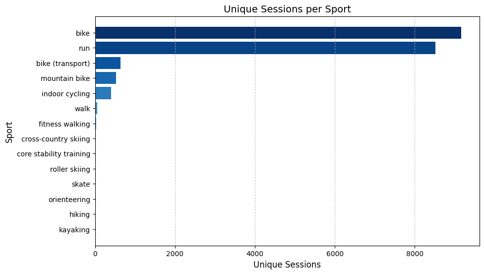

```python
# Sort data for plotting
session_counts_sorted = sport_grouped.sort_values(by='unique_sessions', ascending=False)

# Normalize color range for the number of bars
norm2 = plt.Normalize(0, len(session_counts_sorted))
colors2 = cm.Blues_r(norm2(range(len(session_counts_sorted))))

# Plot for Unique Sessions
fig, ax2 = plt.subplots(figsize=(10, 6))
ax2.barh(session_counts_sorted['sport'], session_counts_sorted['unique_sessions'], color=colors2)
ax2.set_title('Unique Sessions per Sport', fontsize=14)
ax2.set_xlabel('Unique Sessions', fontsize=12)
ax2.set_ylabel('Sport', fontsize=12)
plt.gca().invert_yaxis()  # Highest value at the top
ax2.grid(axis='x', linestyle='--', alpha=0.7)  # Add grid only for x-axis
plt.show()
```

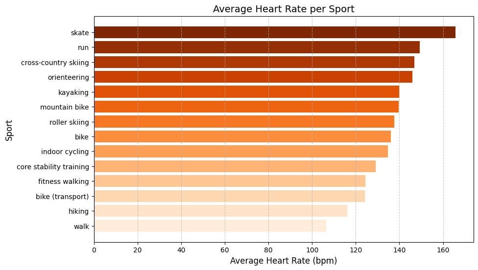

```python
# Sort data for plotting
avg_heart_rate_sorted = sport_grouped.sort_values(by='avg_heart_rate', ascending=False)

# Normalize color range for the number of bars
norm1 = plt.Normalize(0, len(avg_heart_rate_sorted))
colors1 = cm.Oranges_r(norm1(range(len(avg_heart_rate_sorted))))

# Plot for Average Heart Rate
fig, ax1 = plt.subplots(figsize=(10, 6))
ax1.barh(avg_heart_rate_sorted['sport'], avg_heart_rate_sorted['avg_heart_rate'], color=colors1)
ax1.set_title('Average Heart Rate per Sport', fontsize=14)
ax1.set_xlabel('Average Heart Rate (bpm)', fontsize=12)
ax1.set_ylabel('Sport', fontsize=12)
plt.gca().invert_yaxis()  # Highest value at the top
ax1.grid(axis='x', linestyle='--', alpha=0.7)  # Add grid only for x-axis
plt.show()
```

### Group Sports into Categories

```python
# Define the mapping of original sports to new categories
sport_mapping = {
    'bike': 'bike',
    'bike (transport)': 'bike',
    'mountain bike': 'bike',
    'indoor cycling': 'bike',
    'run': 'run'
}

# Map sports into categories; those not in mapping are 'others'
sport_grouped['sport_category'] = sport_grouped['sport'].apply(lambda x: sport_mapping.get(x, 'others'))

# Calculate counts for each category based on 'unique_sessions'
bike_count = sport_grouped.loc[sport_grouped['sport_category'] == 'bike', 'unique_sessions'].sum()
run_count = sport_grouped.loc[sport_grouped['sport_category'] == 'run', 'unique_sessions'].sum()
others_count = sport_grouped.loc[sport_grouped['sport_category'] == 'others', 'unique_sessions'].sum()

# Print the counts for verification
print("Unique Sessions per Category:")
print(f"Bike: {bike_count}")
print(f"Run: {run_count}")
print(f"Others: {others_count}")
```

```
Unique Sessions per Category:
Bike: 10728
Run: 8513
Others: 150
```

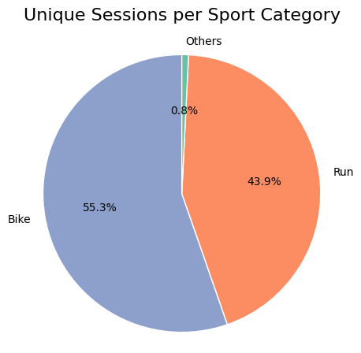

```python
# Define labels and colors
labels = ['Bike', 'Run', 'Others']
colors = ['#8da0cb', '#fc8d62', '#66c2a5']

# Create the pie chart
plt.figure(figsize=(5, 5))
plt.pie(
    x=[bike_count, run_count, others_count],
    labels=labels,
    colors=colors,
    autopct='%1.1f%%',
    startangle=90,
    wedgeprops={'edgecolor': 'white', 'linewidth': 1}
)
plt.title('Unique Sessions per Sport Category', fontsize=16, pad=20)
plt.axis('equal')  # Keeps the chart circular
plt.show()
```

### Workout Patterns by Day and Time

In this section, we analyze workout patterns across different days of the week and times of the day. By examining when users engage in various activities, we can uncover trends in their workout habits, such as preferred workout days, start times, and session durations.

This analysis is based on the following metrics:

- **Day of the Week**: We identify which days are the most popular for workouts across different sports categories.
- **Starting Hour**: By analyzing workout start times, we explore if users prefer morning, afternoon, or evening sessions.
- **Workout Duration**: We calculate the total duration of each workout session, helping us understand typical workout lengths across different days and times.

To do this, we prepared the dataset by:

- For each workout session, we identified the **start and end times** and calculated the duration (in minutes) based on these.
- We also extracted the **day of the week** and **starting hour** from the timestamp to explore weekly trends and preferred workout times.

```python
# Create a copy with relevant columns
day_and_time_data = endomondo_df[['timestamp', 'id', 'sport']].copy()

# Add a new column 'sport_category' using the sport_mapping
day_and_time_data['sport_category'] = day_and_time_data['sport'].map(sport_mapping).fillna('others')

# Ensure timestamp is in datetime format (if not already)
day_and_time_data['timestamp'] = pd.to_datetime(day_and_time_data['timestamp'])

# Extract date and calculate start and end times in a single operation
day_and_time_data['date'] = day_and_time_data['timestamp'].dt.date
day_and_time_data['day_of_week'] = day_and_time_data['timestamp'].dt.day_name()
day_and_time_data['starting_hour'] = day_and_time_data['timestamp'].dt.hour

# Group by id, sport_category, and date to calculate start, end, and duration
day_and_time_summary = day_and_time_data.groupby(['id', 'sport_category', 'date']).agg(
    start_time=('timestamp', 'min'),
    end_time=('timestamp', 'max')
).reset_index()

# Calculate duration in minutes
day_and_time_summary['duration'] = (day_and_time_summary['end_time'] - day_and_time_summary['start_time']).dt.total_seconds() / 60

# Add day of the week and starting hour columns for easier analysis
day_and_time_summary['day_of_week'] = day_and_time_summary['start_time'].dt.day_name()
day_and_time_summary['starting_hour'] = day_and_time_summary['start_time'].dt.hour

# Display the resulting DataFrame
day_and_time_summary.head()
```

|  | id | sport_category | date | start_time | end_time | duration | day_of_week | starting_hour |
| --- | --- | --- | --- | --- | --- | --- | --- | --- |
| 0 | 9633831.0 | bike | 2011-04-24 | 2011-04-24 19:11:23 | 2011-04-24 20:33:03 | 81.666667 | Sunday | 19 |
| 1 | 10544802.0 | bike | 2011-05-07 | 2011-05-07 22:02:58 | 2011-05-07 23:19:46 | 76.800000 | Saturday | 22 |
| 2 | 11426022.0 | bike | 2011-05-19 | 2011-05-19 19:56:06 | 2011-05-19 22:04:24 | 128.300000 | Thursday | 19 |
| 3 | 11639926.0 | bike | 2011-05-22 | 2011-05-22 15:34:38 | 2011-05-22 18:02:38 | 148.000000 | Sunday | 15 |
| 4 | 11908018.0 | bike | 2011-05-25 | 2011-05-25 21:19:51 | 2011-05-25 23:59:31 | 159.666667 | Wednesday | 21 |

#### Workout Sessions by Day of the Week

This section examines user workout patterns across different days of the week, with a focus on understanding how popular each day is for various types of workouts. By analyzing workout sessions per day, we aim to uncover trends such as preferred workout days and weekly workout habits among users.

The analysis includes the following aspects:

- **Day of the Week:** We categorize workouts by day (Monday to Sunday) to identify the most active days and any noticeable trends in weekly activity patterns.
- **Sport Categories:** The workouts are grouped into three categories—Bike, Run, and Others—based on the classification established in earlier sections. This grouping provides insights into the popularity of different sports on each day of the week.

The visualization uses a stacked bar chart, where:

- Each bar represents a day of the week, displaying the total workout sessions for that day.
- The segments within each bar are color-coded by sport type, illustrating the distribution of activities across sports and providing a comparative view of which sports are more popular on certain days.

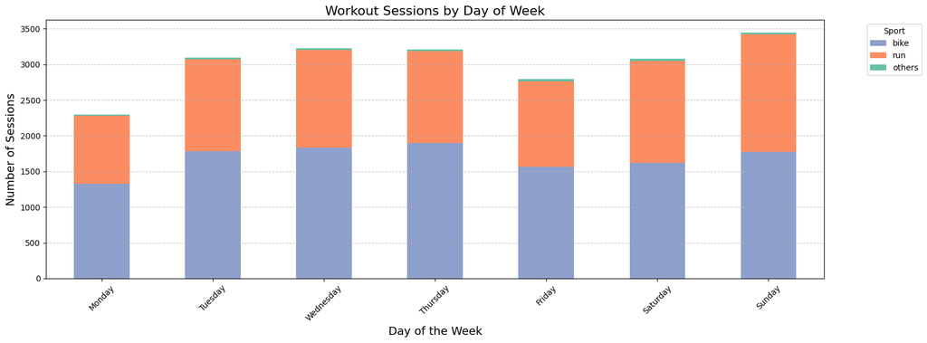

```python
# Sort the data based on day of week
day_order = ['Monday', 'Tuesday', 'Wednesday', 'Thursday', 'Friday', 'Saturday', 'Sunday']
day_and_time_summary['day_of_week'] = pd.Categorical(day_and_time_summary['day_of_week'], categories=day_order, ordered=True)

# Prepare the data required for visualization
workout_session_by_day_of_week = day_and_time_summary.groupby(['day_of_week', 'sport_category'], observed=False).size().unstack(fill_value=0)

# Reorder columns for consistent colors
workout_session_by_day_of_week = workout_session_by_day_of_week[['bike', 'run', 'others']]

# Visualize data in a stacked bar chart
ax = workout_session_by_day_of_week.plot(kind='bar', stacked=True, figsize=(16, 6), color=colors)
plt.title('Workout Sessions by Day of Week', fontsize=16)
plt.xlabel('Day of the Week', fontsize=14)
plt.ylabel('Number of Sessions', fontsize=14)
plt.xticks(rotation=45)
ax.grid(axis='y', linestyle='--', alpha=0.7)
plt.legend(title='Sport', bbox_to_anchor=(1.05, 1), loc='upper left')
plt.tight_layout()
plt.show()
```

#### Workout Sessions by Hour of Day

In this section, we explore the distribution of workout sessions throughout the day, segmented by hour and categorized by sport type.

The analysis includes the following metrics:

- **Hour of the Day:** The data is categorized by the hour in which users started their workouts. This helps to determine whether users prefer morning, afternoon, or evening sessions.
- **Sport Categories:** For consistency, the workouts are grouped into three categories: Bike, Run, and Others, based on the earlier-defined classification.

The visualization uses a stacked bar chart, where:

- Each bar represents an hour of the day, from 0 (midnight) to 23 (11 PM).
- The segments within each bar show the distribution of workout sessions by sport type, helping to visualize the popularity of each sport type at different times of the day.

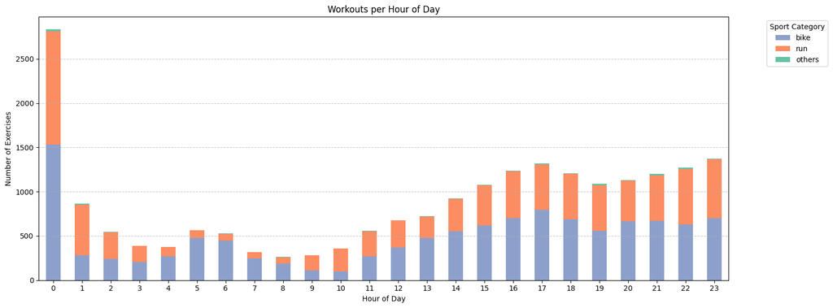

```python
# User workout sessions by type of sport and hour of day

# Sort the data based on day of week
hour_order = [i for i in range(24)]
day_and_time_summary['starting_hour'] = pd.Categorical(day_and_time_summary['starting_hour'], categories=hour_order, ordered=True)

# Prepare the data required for visualisation
workout_session_by_hour_of_day = day_and_time_summary.groupby(['starting_hour', 'sport_category'], observed=False).size().unstack(fill_value=0)

# Reorder columns for consistent colours
workout_session_by_hour_of_day = workout_session_by_hour_of_day[['bike', 'run', 'others']]

# Visualise data in a stacked bar chart
workout_session_by_hour_of_day.plot(kind='bar', stacked=True, color=colors, figsize=(16, 6))
plt.title('Workouts per Hour of Day')
plt.xlabel('Hour of Day')
plt.ylabel('Number of Exercises')
plt.xticks(rotation=0)
plt.legend(title='Sport Category', bbox_to_anchor=(1.05, 1), loc='upper left')
plt.grid(axis='y', linestyle='--', alpha=0.7)
plt.tight_layout()
plt.show()
```

#### Workout Sessions by duration

In this section, we analyze the distribution of workout sessions based on their duration. By examining the length of workout sessions, we can gain insights into common workout durations and how long users typically engage in their activities.

The histogram provides a visual representation of workout session lengths across the dataset:

- **X-Axis (Length in Minutes):** The workout durations are grouped into 10-minute bins, ranging from 0 to 300 minutes.
- **Y-Axis (Number of Workout Sessions):** This axis represents the number of sessions that fall within each duration range.

This visualization helps identify the most frequent workout durations and offers a sense of how long users spend on their workouts.

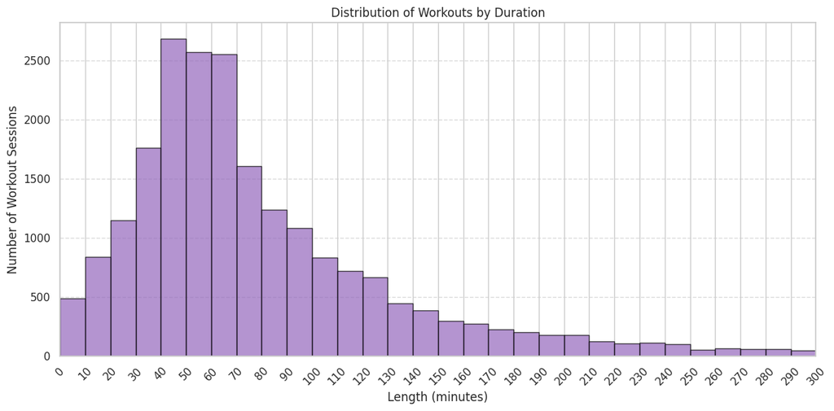

```python
sns.set(style="whitegrid")

# Define the bin edges for the histogram
bin_edges = [i for i in range(0, 310, 10)]

# Plot the histogram for workout session durations
plt.figure(figsize=(12, 6))
plt.hist(day_and_time_summary['duration'], bins=bin_edges, edgecolor='black', color="#9467bd", alpha=0.7)
plt.title('Distribution of Workouts by Duration')
plt.xlabel('Length (minutes)')
plt.ylabel('Number of Workout Sessions')
plt.xticks(bin_edges, rotation=45)
plt.xlim(bin_edges[0], bin_edges[-1])
plt.grid(axis='y', linestyle='--', alpha=0.7)
plt.tight_layout()
plt.show()
```

### Observations

**Average Heart Rate per Sport:**

- Expectedly, Walking has the lowest Average Heart Rate, with Hiking as the second lowest
- Skating quite clearly has the highest Average Heart Rate, which is unexpected, given that there are arguably more intensive sports like running in the dataset

**Unique Session per Sport:**

- From the bar chart, we can clearly see that Bike and Run are overwhelmingly the most popular sports based on our data
- Also the next few (distant) popular sports are all also bike-related: Bike (Transport), Mountain Bike, and Indoor Cycling

**Workouts per Day of Week:**

- Distribution is different from what we expected. One would expect that there would be a significantly larger amounts of workout performed during the weekends but this does not appear to be the case
- Workouts seem to be fairly evenly distributed across the week, with notably lower number of workouts performed on Mondays and Fridays. Workouts on the other days in the week seems fairly equal though.

**Workouts per Hour of Day:**

- There is a surprisingly high number of workouts recorded between 12:00 AM and 1:00 AM, which is significantly higher than expected, almost twice compared to any other 1-hour intervals during the day.
- That said, most of the workouts occur between 1600H and 2359H, which is within expectations

> *Timezone Assumption: These patterns may be influenced by the absence of timezone information in the dataset. All timestamps are recorded in the same, unknown timezone, which may skew the distribution of workouts across different times of day and days of the week. For instance, the large number of midnight workouts might actually correspond to workouts conducted in the late evening or early morning in a different timezone.*

**Distribution of Workouts by Duration:**

- Most workout durations lie between 30 mins and 80 mins, which is within expectations.

## 2 Predictive Analysis

### Problem Definition

In this section, we explore whether workout intensity can be classified based on various workout features included in and derived from the dataset, such as:

- Speed
- Heart Rate
- Elevation (Altitude)
- Workout duration

By predicting the intensity of workouts, users can gain insights into how strenuous their workouts are and make informed adjustments as needed. The classification of workout intensity into categories such as High, Medium, and Low provides a clear metric for users to monitor and evaluate their progress.

Through this analysis, we aim to:

- Classify workout sessions into intensity levels based on available features.
- Predict the intensity of new workout sessions, allowing for real-time feedback and adjustments.

The insights from this predictive model can help users optimize their training efforts by ensuring they’re working out at their desired intensity levels. It also facilitates goal-setting and monitoring, making it easier to align workouts with fitness objectives.

#### Training a model to classify workouts by intensity

In a supervised learning scenario, models like K-Nearest Neighbors (KNN) or Random Forest would be ideal for classification tasks, especially when we have labeled data. These models can be fine-tuned by comparing predicted labels against the ground truth, optimizing performance.

However, since our dataset is unlabeled, we resort to unsupervised learning techniques for clustering. After considering k-means clustering, DBSCAN, and hierarchical clustering, we ultimately chose k-means for this task.

Although DBSCAN could be useful for identifying clusters of irregular shapes or handling noise, it is not the most suitable method in our case due to the difficulty in defining the epsilon parameter, which is crucial to its performance. Since we lack a semantically meaningful way to determine epsilon, DBSCAN was ruled out.

Similarly, we did not select hierarchical clustering because it is less practical for our needs—it is computationally expensive to reassign new data points to clusters, and it doesn’t directly offer a fixed number of clusters, which is essential for our goal.

Therefore, we chose k-means clustering as it is more appropriate when the number of clusters is known in advance. In this case, we want to group workouts into three categories: high intensity, medium intensity, and low intensity. We performed k-means clustering to obtain three clusters and then conducted a manual review to map each cluster to its respective intensity level.

```python
from sklearn.cluster import KMeans
from sklearn.preprocessing import MinMaxScaler
```

```python
number_of_workout_intensity_levels = 3 # high, medium, low
random_seed_for_reproducibility = 42
number_of_samples_to_review_per_cluster = 10

pd.set_option('display.max_rows', number_of_samples_to_review_per_cluster)  # Show all rows
pd.set_option('display.max_columns', None)  # Show all columns
pd.set_option('display.width', 1000)  # Set width for better formatting

# Prepare data
# - need to "consolidate" data for each user for their entire workout because it does not make sense to cluster each part of a user's workout
# - max and min heart rate, as well as the total heart rate range are included because:
#     - fitter individuals tend to have lower resting heart rates and experience smaller increases in heart rate during exercise compared to less fit individuals, even when performing workouts of the same intensity
#     - therefore using the range of heart rates recorded during the workout alone would not be accurate
# - features for k-means clustering
#     - max heart rate
#     - min heart rate
#     - change in heart rate
#     - change in altitude (computed as the cumulative sum of abs(altitude_diff) for the entire workout)
#     - workout duration (same computation logic as above)
#     - distance travelled (same computation logic as above)
#     - average speed (recomputed as distance / time) (not sure if it matters but ideally should provide time-weighted average speed for best chance of good results?)

def prepare_data(
    data, # endomondo_df
    sport, # "bike" or "run"
):
    # Ensure 'timestamp' column is in datetime format
    data['timestamp'] = pd.to_datetime(data['timestamp'])

    # Filter data for the specified sport
    filtered_data = data[data['sport'] == sport].copy() # copy data
    results = pd.DataFrame(filtered_data['id']).drop_duplicates()

    # Calculate altitude_diff if it does not exist
    if 'altitude_diff' not in filtered_data.columns:
        filtered_data['altitude_diff'] = filtered_data.groupby('id')['altitude'].diff().fillna(0)

    # Calculate time_elapsed if it does not exist
    if 'time_elapsed' not in filtered_data.columns:
        filtered_data['time_elapsed'] = filtered_data.groupby('id')['timestamp'].diff().dt.total_seconds().fillna(0)

    # Calculate speed_diff if it does not exist
    if 'speed_diff' not in filtered_data.columns:
        filtered_data['speed_diff'] = filtered_data.groupby('id')['speed'].diff().fillna(0)

    # retrieve max heart rate
    max_heart_rates = filtered_data.groupby('id')['heart_rate'].max().reset_index(name='max_heart_rate')
    results = pd.merge(results, max_heart_rates, on='id', how='left')

    # retrieve min heart rate
    min_heart_rates = filtered_data.groupby('id')['heart_rate'].min().reset_index(name='min_heart_rate')
    results = pd.merge(results, min_heart_rates, on='id', how='left')

    # compute the total range of heart rate
    results['heart_rate_range'] = results['max_heart_rate'] - results['min_heart_rate']

    # compute the change in altitude
    filtered_data.loc[:, 'absolute_altitude_diff'] = filtered_data['altitude_diff'].abs()
    altitudes = filtered_data.groupby('id')['absolute_altitude_diff'].sum().reset_index()
    results = pd.merge(results, altitudes, on='id', how='left')

    # compute workout duration
    durations = filtered_data.groupby('id')['timestamp'].agg(
        workout_time=lambda x: (x.max() - x.min()).total_seconds()
    ).reset_index()
    results = pd.merge(results, durations, on='id', how='left')

    # compute distance travelled
    filtered_data.loc[:,'distance_travelled'] = filtered_data['time_elapsed'] * (filtered_data['speed']*1000/3600 - filtered_data['speed_diff']*1000/3600) # assuming speed is in km/h, convert to m/s
    distances = filtered_data.groupby('id')['distance_travelled'].sum().reset_index()
    results = pd.merge(results, distances, on='id', how='left')

    # compute average speed
    results['avg_speed'] = results['distance_travelled'] / results['workout_time']

    return results

bike_data_for_k_means = prepare_data(endomondo_df, 'bike')
run_data_for_k_means = prepare_data(endomondo_df, 'run')
```

```python
# normalise the data before performing k-means clustering
bike_min_max_scaler = MinMaxScaler()
run_min_max_scaler = MinMaxScaler()

bike_data_for_k_means_scaled = bike_min_max_scaler.fit_transform(bike_data_for_k_means.loc[:, bike_data_for_k_means.columns != 'id']) # id excluded from k-means clustering
run_data_for_k_means_scaled = run_min_max_scaler.fit_transform(run_data_for_k_means.loc[:, run_data_for_k_means.columns != 'id']) # id excluded from k-means clustering

# perform k-means clustering
bike_k_means = KMeans(n_clusters=number_of_workout_intensity_levels, init="k-means++")
bike_data_for_k_means["cluster"] = bike_k_means.fit_predict(bike_data_for_k_means_scaled)

run_k_means = KMeans(n_clusters=number_of_workout_intensity_levels, init="k-means++")
run_data_for_k_means["cluster"] = run_k_means.fit_predict(run_data_for_k_means_scaled)
```

```python
# function to help with visualising the results
# - shape is not implemented at the moment, logic of function will need to change if we are also plotting different shapes
def visualise_clusters(sport, data, min_max_scaler, k_means_model, x_axis, y_axis, color=None, size=None):
    # Create a scatter plot of the data, with a different shape for each cluster
    plt.figure(figsize=(10, 10))
    if size:
      scatter = plt.scatter(data[x_axis], data[y_axis], c=data[color], s=data[size], cmap='viridis', alpha=0.6)
    else:
      scatter = plt.scatter(data[x_axis], data[y_axis], c=data[color], cmap='viridis', alpha=0.6)

    # Add cluster centroids to the plot
    # - the centroids are normalised so we would need to reverse the normalisation before plotting them
    centroids = pd.DataFrame(min_max_scaler.inverse_transform(k_means_model.cluster_centers_), columns=data.columns[1:-1]) # reverse the normalisation before plotting, remove "id" and "cluster" columns
    plt.scatter(centroids[x_axis], centroids[y_axis], color='red', marker='x', s=100, label='Centroids')

    # Add labels and legend
    plt.title(f'{sport} workouts clustered for intensity of workout')
    plt.xlabel(x_axis)
    plt.ylabel(y_axis)
    plt.legend(*scatter.legend_elements(), title='Clusters')
    plt.grid(True, linestyle='--', alpha=0.6)
    plt.show()
```

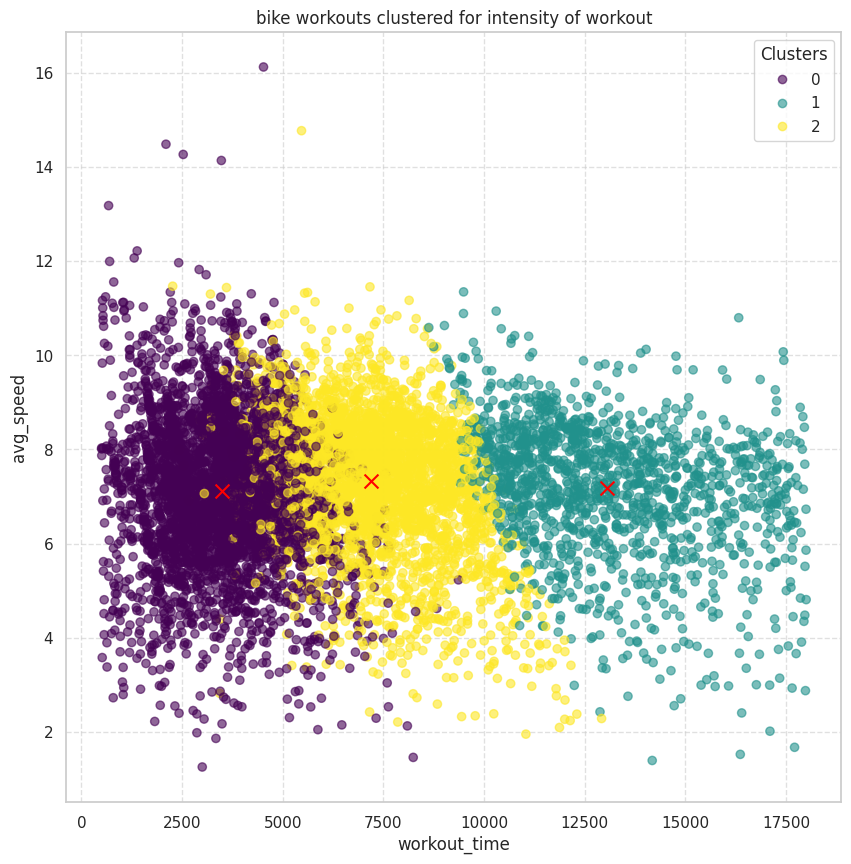

```python
visualise_clusters(sport = 'bike',
                   data = bike_data_for_k_means,
                   min_max_scaler = bike_min_max_scaler,
                   k_means_model = bike_k_means,
                   x_axis = 'workout_time',
                   y_axis = 'avg_speed',
                   color = 'cluster',
                   size = None # suggest not to use because the chart will look very chaotic
                   )
```

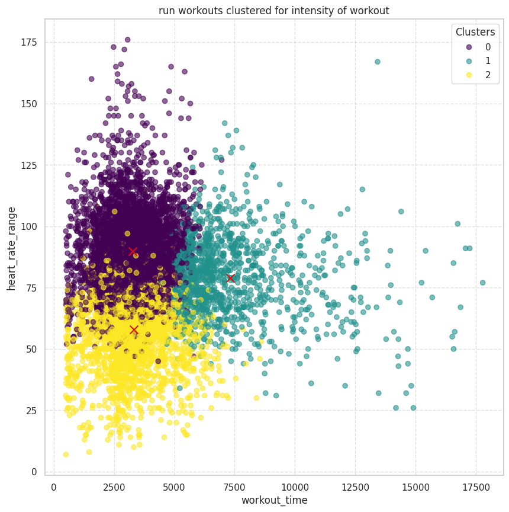

```python
visualise_clusters(sport = 'run',
                   data = run_data_for_k_means,
                   min_max_scaler = run_min_max_scaler,
                   k_means_model = run_k_means,
                   x_axis = 'workout_time',
                   y_axis = 'heart_rate_range',
                   color = 'cluster',
                   size = None # suggest not to use because the chart will look very chaotic
                   )
```

### Manual review to assign clusters to intensity levels

```python
# sample 10 datapoints from each cluster
def pick_samples(data, seed, cluster_number, number_of_samples):
    return data[data["cluster"] == cluster_number].sample(n=number_of_samples, random_state=seed)

for sport in ["bike", "run"]:
    data = bike_data_for_k_means if sport == "bike" else run_data_for_k_means
    for i in range(number_of_workout_intensity_levels):
        print(f"------ Cluster {i} for {sport} ------")
        print(pick_samples(data, random_seed_for_reproducibility, i, number_of_samples_to_review_per_cluster))
        print("--------------------------------")
```

```
------ Cluster 0 for bike ------
               id  max_heart_rate  min_heart_rate  heart_rate_range  absolute_altitude_diff  workout_time  distance_travelled  avg_speed  cluster
8985  153600531.0             147              97                50                   471.4        2407.0        17110.056889   7.108457        0
1118  608237741.0             162              76                86                   133.0        3588.0        26572.929000   7.406056        0
5823  292795815.0             170              91                79                   804.0        4095.0        28278.976000   6.905733        0
5064   39155638.0             158             110                48                   148.2        2307.0        19478.910000   8.443394        0
7757  541545319.0             109              73                36                    17.8         869.0         4758.636000   5.475991        0
8471  291206188.0             157              90                67                   605.2        5742.0        35834.290000   6.240733        0
236   400519148.0             138              80                58                   158.8        6723.0        43426.794000   6.459437        0
4912  362857732.0             147             111                36                   102.8        2349.0        19357.948000   8.240931        0
3301  620326849.0             129             104                25                    51.4        3756.0        26039.651000   6.932814        0
2788  659387435.0             184              99                85                   419.4        3808.0        39985.417000  10.500372        0
--------------------------------
------ Cluster 1 for bike ------
               id  max_heart_rate  min_heart_rate  heart_rate_range  absolute_altitude_diff  workout_time  distance_travelled  avg_speed  cluster
```

[output cut: 63 more lines]

As the cluster numbers may change from one execution of k-means clustering to the next, we cannot specify in this script the mapping of the clusters 0, 1, and 2 to high, medium, and low intensity.

However, from our manual review performed, the clusters do indeed seem to accurately cluster the workouts into high, medium, and low intensity workouts.

### Predicting Intensity of Unseen Workout

```python
# create fictitious bike workout details (manipulated to be of high intensity)
new_workout = pd.DataFrame({'max_heart_rate': [180],
                            'min_heart_rate': [60],
                            'heart_rate_range': [120],
                            'absolute_altitude_diff': [1000],
                            'workout_time': [10800],
                            'distance_travelled': [129600],
                            'avg_speed': [12]})

new_workout_scaled = bike_min_max_scaler.transform(new_workout)

# Finding the cluster of the new workout, assuming the trained k-means model is available
predicted_cluster = bike_k_means.predict(new_workout_scaled)
print(f"The cluster of the new workout based on the trained k-means model is {predicted_cluster[0]}.")

# Finding the cluster of the new workout with the cluster centroids, assuming the trained k-means model is no longer available but the centroids are stored
def find_closest_centroid(data_point, centroids):
    """
    Finds the closest centroid to a given data point.

    Args:
      data_point: A list or numpy array representing the data point.
      centroids: A list of lists or a numpy array representing the centroids.

    Returns:
      The index of the closest centroid.
    """
    distances = [np.linalg.norm(np.array(data_point) - np.array(centroid)) for centroid in centroids]
    return np.argmin(distances)

bike_centroids = bike_k_means.cluster_centers_

closest_centroid_index = find_closest_centroid(new_workout_scaled, bike_centroids)

# Print the closest centroid index
print(f"The closest centroid to the new workout is centroid {closest_centroid_index}, i.e., the new workout belongs to cluster {closest_centroid_index}.")
```

```
The cluster of the new workout based on the trained k-means model is 1.
The closest centroid to the new workout is centroid 1, i.e., the new workout belongs to cluster 1.
```

With the closest centroid to the new workout identified, we can then map the new workout to either high, medium, or low intensity based on the mapping determined through manual review of the clustering results performed above

### Conclusion

Through our model using k-means clustering, we are able to predict the intensity of a new unseen workout instance. Therefore, we hope that our model would e able to enable users to make informed decisions about adjusting their workout intensity, helping them stay on track to achieve their fitness goals.